# Alcohol Consumption and Average Grades¶

# A Dataset Introduction

The dataset provides a comprehensive profile of secondary school students, capturing demographic, academic, family, and lifestyle information with the goal of understanding academic performance, particularly final grades in Math or Portuguese (G3). Students attend either the Gabriel Pereira (GP) or Mousinho da Silveira (MS) schools (school), and are identified by sex (male or female) and age (ranging from 15 to 22). Key family background variables include address (urban or rural), famsize, Pstatus (whether parents live together), and parental education levels (Medu, Fedu) and jobs (Mjob, Fjob). The dataset also notes the reason for school choice and the student’s guardian.

Academic behavior is described through traveltime, studytime, and failures, while support and enrichment opportunities are recorded through schoolsup, famsup, paid, activities, and early childhood education (nursery). Aspirations for higher education (higher) and household internet access (internet) are also included. Social and behavioral factors such as romantic relationship status, family relationship quality (famrel), leisure time (freetime, goout), alcohol consumption (Dalc, Walc), health status, and absences provide further context.

Finally, student performance is tracked via three grades—G1, G2, and G3—with G3 serving as the target variable for performance analysis. This rich dataset allows for multifaceted exploration of factors influencing student outcomes

# Predictors of Average Grades.

- Does alcohol consumption have any predictive power over student average grades?
- How does this differ by gender?

I am also interested in learning what other features may be important predictors of student grades. I am not going to attempt to predict student grade evolution over marking periods since all the features in the dataset (other than grades) remain constant over marking periods and are general descriptors of student backgrounds. This study investigates whether alcohol consumption meaningfully predicts student academic performance, and whether this relationship differs by gender. After merging math and Portuguese course data, we created a comprehensive dataset with average grades as the outcome variable.

A linear regression model using over 30 socioeconomic, academic, and behavioral covariates reveals that weekend alcohol consumption (Walc) is a statistically significant negative predictor of average grades among male students only, while weekday alcohol use (Dalc) does not show a significant effect for either gender. The inclusion of interaction terms between alcohol variables and gender significantly improves model fit, as confirmed by an ANOVA test (p = 0.00318), rejecting the null hypothesis that gender does not modify the effect of alcohol use on grades.

I first conduct some EDA to see if the two tables (with math and Portuguese grades) can be combined. After combining the two tables, I obtain student average grades over marking periods and estimate a linear model with gender differencing after fine tuning to explore differences

## ETL (Explore, Transform, Load)

First, *I would ideally like to combine both tables into one*. But before that I would like to get a feeling if math and Portuguese grades are comparable. There is a number of students who are repeated in both tables, so I would use their records to examine if math and Portuguese grades are comparable.

There are 85 students who belong to both tables, and I am going to examine their average math and Portuguese grades as a test case. Once we clarify the relationship between the porteguese and math class, we can determine whether or not to merge the datasets.

### Data Prep: Can we merge the datasets?

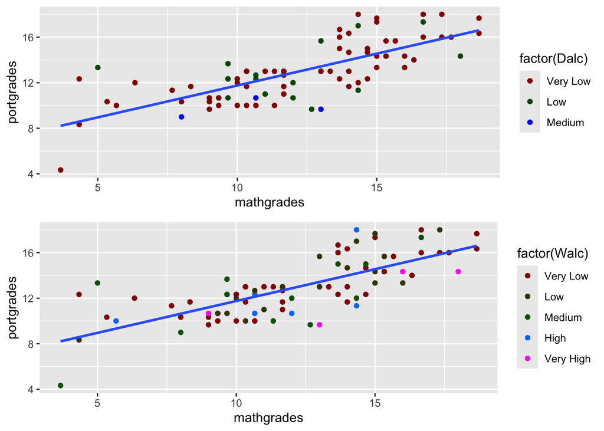

The two scatter plots have few implications. First, among the 85 students, **no one consumed high or very high levels of alcohol on daily basis**. Second, almost all of those who earned relatively high scores consumed very low levels of alcohol on weekdays. These two are expected outcomes. Third, **math and Portuguese grades seem to correlate highly with each other**. When I calculate the correlation, it is about 0.74. Upon regressing the two, about 55% of the variation in Portuguese grades can be explained by the variation in math grades. In my view, this is an indication that I can go ahead and combine the two tables together without worrying much about the subject matter, average grades in math or Portuguese reflect general student aptitude. The resulting dataset is binded by distinct values and has 959 observations, since we removed duplicate values.

## What does the distribution of average grade by alcohol consumption look like?

Now a basic boxplot of average subject grades grouped by the levels of daily alcohol consumption.

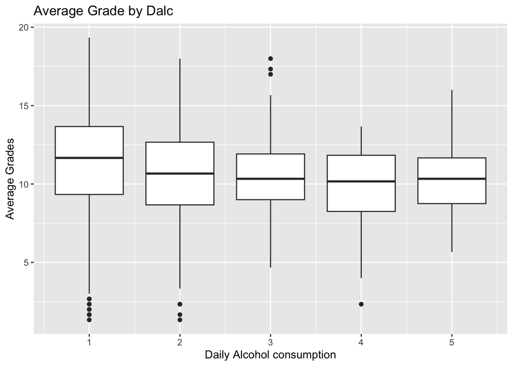

The median average grade is visually **higher** among those students who had very low levels of daily alcohol consumption. However, the median grade of the students with medium, high, and very high levels of daily alcohol consumption doesn’t seem to be very different.

## What about average grades and gender?

We would also like to see if there is a gender difference in average grades

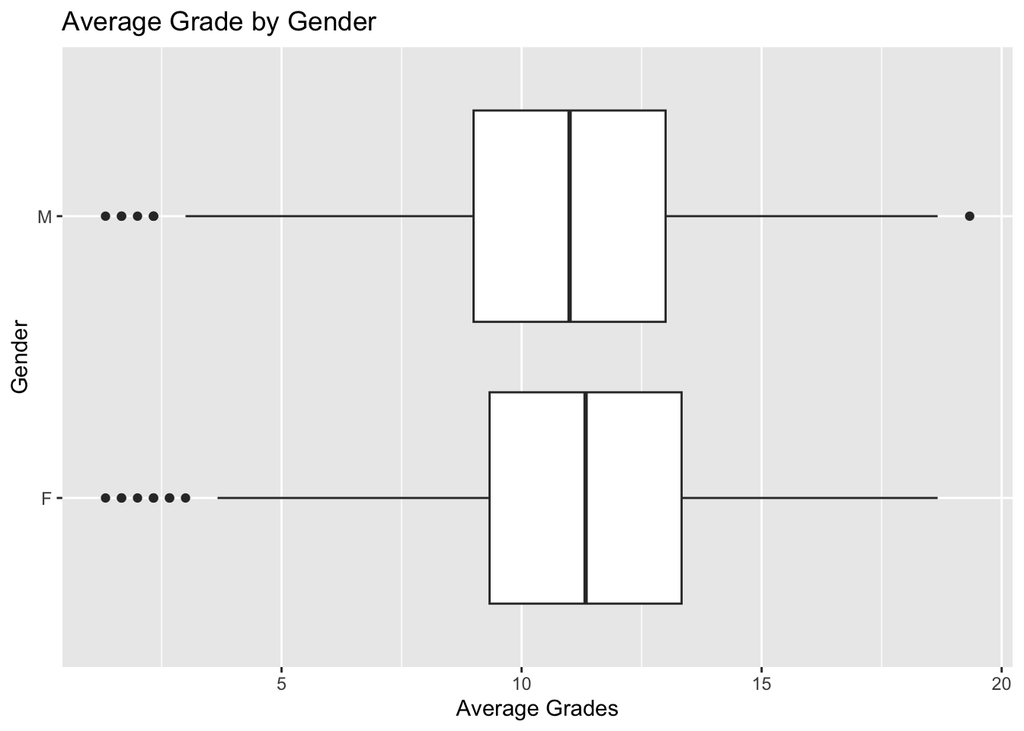

We can see from this that Females appears slightly **left-skewed, with a longer tail on the lower end**, while Males appear more symmetric. Both genders have a similar interquartile range (IQR). However, females show more extreme low outliers—multiple points below the whisker—suggesting a larger concentration of very low scores.

## Effect Modeling

Now that we have a good grasp of alcohol consumption and gender on average grades, we can make a model to see the important predictors. We will first start off by doing a full regression model, but only displaying model fit statistics and significant covariates.

> Variable “failures” is closely related to my target variable, avggrades. Since past failures and avggrades represent the same general student aptitude (thus it is rather a target rather than a feature), I will remove variable “failures” from the dataset.

### Linear Model

```
##
## Significant Variables:
```

```
##                Estimate Std. Error   t value     Pr(>|t|)
## (Intercept)  10.6017499 1.81391104  5.844691 7.041473e-09
## famsizeLE3    0.4975437 0.22194908  2.241702 2.521833e-02
## studytime     0.5080568 0.12725014  3.992583 7.056569e-05
## schoolsupyes -1.5979812 0.31901871 -5.009052 6.556967e-07
## paidyes      -0.6938560 0.24135831 -2.874796 4.136078e-03
## higheryes     1.9236766 0.36185641  5.316133 1.330880e-07
## romanticyes  -0.4996783 0.20970751 -2.382739 1.738657e-02
## goout        -0.2127131 0.09953787 -2.137006 3.286063e-02
## health       -0.1562929 0.07097167 -2.202187 2.789957e-02
```

```
##
## Other Variables of Interest:
```

```
##         Estimate Std. Error    t value  Pr(>|t|)
## sexM -0.12157726  0.2255528 -0.5390190 0.5900041
## Dalc -0.13031412  0.1389503 -0.9378472 0.3485691
## Walc -0.02105433  0.1092166 -0.1927759 0.8471770
```

```
##
## Model Fit:
```

```
## R-squared:  0.2015
```

```
## Adjusted R-squared:  0.1685
```

We now have a good idea of what predictors are significant, and now we can test interaction terms.

```
## Significant predictors (p < 0.05):
```

```
##                Estimate Std. Error   t value     Pr(>|t|)
## (Intercept)   9.7936749 1.83755041  5.329745 1.238267e-07
## sexM          1.0738754 0.47520205  2.259829 2.406553e-02
## famsizeLE3    0.5372783 0.22113981  2.429587 1.530694e-02
## Fjobteacher   1.1858909 0.60210001  1.969591 4.918556e-02
## studytime     0.5311143 0.12678719  4.189022 3.071834e-05
## schoolsupyes -1.5923229 0.31783927 -5.009837 6.533518e-07
## paidyes      -0.6891791 0.24016647 -2.869589 4.204378e-03
## higheryes     1.8410618 0.36085052  5.102007 4.083834e-07
## romanticyes  -0.4578926 0.20907037 -2.190136 2.876531e-02
## health       -0.1453339 0.07080159 -2.052692 4.038546e-02
## sexM:Walc    -0.6255661 0.19970414 -3.132464 1.788404e-03
```

```
##
## Model Fit:
```

```
## R-squared:  0.2115
```

```
## Adjusted R-squared:  0.1771
```

After controlling for 30+ socioeconomic, academic, and behavioral variables, weekend alcohol consumption (Walc) significantly predicts lower academic performance among male students, but not females. Weekday alcohol use (Dalc) showed no significant predictive power in either gender.

**An important question to ask: Why are we testing both effects and interactions (X*Y=X+Y+XY) instead of (X:Y=XY)?**

While individual effects of alcohol use (Dalc, Walc) and gender (sex) were not always statistically significant on their own, the interaction between weekend alcohol use and gender (Walc:sex) was highly significant. This indicates that the effect of alcohol on grades is conditional on gender — a classic case where interaction modeling is essential. Following statistical best practices, we retained main effects alongside interaction terms to ensure proper model specification and accurate interpretation of conditional relationships.

```
## Analysis of Variance Table
##
## Model 1: avggrades ~ school + sex + age + address + famsize + Pstatus +
##     Medu + Fedu + Mjob + Fjob + reason + guardian + traveltime +
##     studytime + schoolsup + famsup + paid + activities + nursery +
##     higher + internet + romantic + famrel + freetime + goout +
##     Dalc + Walc + health + absences
## Model 2: avggrades ~ Dalc * sex + Walc * sex + school + age + address +
##     famsize + Pstatus + Medu + Fedu + Mjob + Fjob + reason +
##     guardian + traveltime + studytime + schoolsup + famsup +
##     paid + activities + nursery + higher + internet + romantic +
##     famrel + freetime + goout + health + absences
##   Res.Df    RSS Df Sum of Sq      F   Pr(>F)
## 1    920 7968.1
## 2    918 7868.9  2    99.231 5.7883 0.003176 **
## ---
## Signif. codes:  0 '***' 0.001 '**' 0.01 '*' 0.05 '.' 0.1 ' ' 1
```

The interaction terms significantly improve the model fit. Since the p-value is 0.00318, you reject the null hypothesis that the simpler model is sufficient. **The effect of alcohol consumption on grades significantly differs by gender.**

## Results

Our findings show that the effect of alcohol consumption on academic performance is *not uniform* across genders. Specifically, weekend drinking negatively affects male students’ grades, while no such effect is observed for females. This suggests targeted interventions may be warranted for different groups.

Social research should prioritize causal inference, robustness, and effect size interpretation, not just variance explained. Endogeneity, omitted variables, and selection bias are more prevelant in observational studies.

# Conclusions

1. Does alcohol consumption have any predictive power over student average grades?

Yes — alcohol consumption does show some predictive power over student average grades, particularly weekend drinking (Walc). In a fully adjusted linear regression model that controls for over 30 covariates, higher weekend alcohol use was associated with lower average grades, although this effect was not significant, and either was Weekday drinking (Dalc), suggesting that the timing and context of alcohol use may matter more than frequency alone.

2. How does this differ by gender?